# Fisseha Berhane, PhD

#### Data Scientist

443-970-2353 fisseha@jhu.edu CV Resume

### **Downloading data from the web using R**

Since I am using Ipython notebook (Jupyter), I am setting the option below so as to make my figures inline.

```r
options(jupyter.plot_mimetypes = 'image/png')
```

There are different ways that we can download and read data into R. Some examples are shown below.

### Example 1

The American Community Survey distributes downloadable data about United States communities. Let's download the 2006 microdata survey about housing for the state of Idaho using download.file() from here:

https://d396qusza40orc.cloudfront.net/getdata%2Fdata%2Fss06hid.csv

and load the data into R. The code book, describing the variable names is here:

https://d396qusza40orc.cloudfront.net/getdata%2Fdata%2FPUMSDataDict06.pdf

Setting the working directory

```r
setwd("C:/Fish/classes/summer_2015/getting_cleaning_data/quizes")
```

The code below checks if the data is already downloaded, if not it downloads it.

```r
if(!file.exists('q1.csv')){
    url<-"https://d396qusza40orc.cloudfront.net/getdata%2Fdata%2Fss06hid.csv"

    download.file(url,destfile = "q1.csv")
}
```

Then let's read the data into R

```r
data<-read.csv("q1.csv")
```

We can perform calculations on the using the data. For example, let's calculate how many properties are worth $1,000,000 or more.  
From the code book, we can see that the variable 'VAL' is property value and 24 represents properies that worth 1000000+. So let's use the table command to see how many properties are worth what.

```
x
  1   2   3   4   5   6   7   8   9  10  11  12  13  14  15  16  17  18  19  20
 75  42  33  30  26  29  23  70  99 119 152 199 233 495 483 486 357 502 232 312
 21  22  23  24
164 159  47  53
```

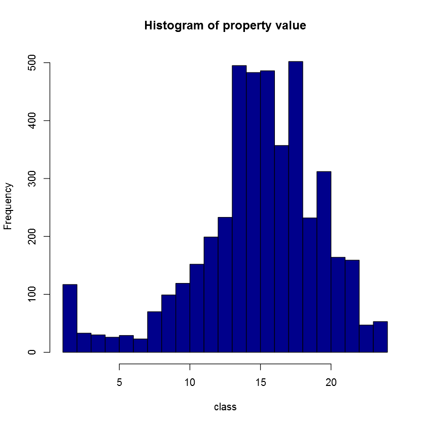

```r
x<-data$VAL
table(x)
hist(x,breaks=24,xlab='class',main='Histogram of property value',col='darkblue')
```

So, we can see from column 24 that there are 53 properties worth 1000000+ or more

### Example 2

Now let's see how to read extensible markup language(XML) data which is frequently used to store structured data, and widely used in internet apps. It is known that extracting XML is basis for most of web scraping  
Let's read the XML data on Baltimore restaurants from here: https://d396qusza40orc.cloudfront.net/getdata%2Fdata%2Frestaurants.xml.

Then let's see how many restaurants have zipcode 21218, where my office is located.

Check if XML package is present, else download it.

```r
if(!require(XML)){
    install.packages('XML')}
```

Load XML package and download data. I have replaced https by httP to make it downloadable.

```r
library(XML)

fileURL<-"https://d396qusza40orc.cloudfront.net/getdata%2Fdata%2Frestaurants.xml"

fileURL2 <- sub('https', 'http', fileURL)
doc <- xmlTreeParse(fileURL2, useInternal = TRUE)
```

Now, let's get the rootnode and explore it.

```r
rootNode<-xmlRoot(doc)
xmlName(rootNode)

names(rootNode)

rootNode[[1]][[1]];
```

"response"

**row:** "row"

```
<row _id="1" _uuid="93CACF6F-C8C2-4B87-95A8-8177806D5A6F" _position="1" _address="http://data.baltimorecity.gov/resource/k5ry-ef3g/1">
  <name>410</name>
  <zipcode>21206</zipcode>
  <neighborhood>Frankford</neighborhood>
  <councildistrict>2</councildistrict>
  <policedistrict>NORTHEASTERN</policedistrict>
  <location_1 human_address="{&quot;address&quot;:&quot;4509 BELAIR ROAD&quot;,&quot;city&quot;:&quot;Baltimore&quot;,&quot;state&quot;:&quot;MD&quot;,&quot;zip&quot;:&quot;&quot;}" needs_recoding="true"/>
</row>
```

Now, let's see the number of restaurants with zipcode 21218

```r
zipcode<-xpathSApply(rootNode,"//zipcode",xmlValue)

sum(zipcode=='21218')
```

69

So, there are 69 restaurants with zipcode 21218.

We can also see histogram of restaurants by zipcode.

```r
zipcode<-as.numeric(zipcode)

x<-unique(zipcode)
x
```

1. 21206

2. 21231

3. 21224

4. 21211

5. 21223

6. 21218

7. 21205

8. 21226

9. 21215

10. 21202

11. 21201

12. 21230

13. 21222

14. 21212

15. 21210

16. 21213

17. 21214

18. 21225

19. 21217

20. 21234

21. 21209

22. 21227

23. 21239

24. 21216

25. 21208

26. 21207

27. 21229

28. 21251

29. 21220

30. 21287

31. -21226

32. 21237

Let's remove the negative value.

```r
zipcode<-zipcode[zipcode>0]
```

Let's see a histogram of restaurants by zipcode

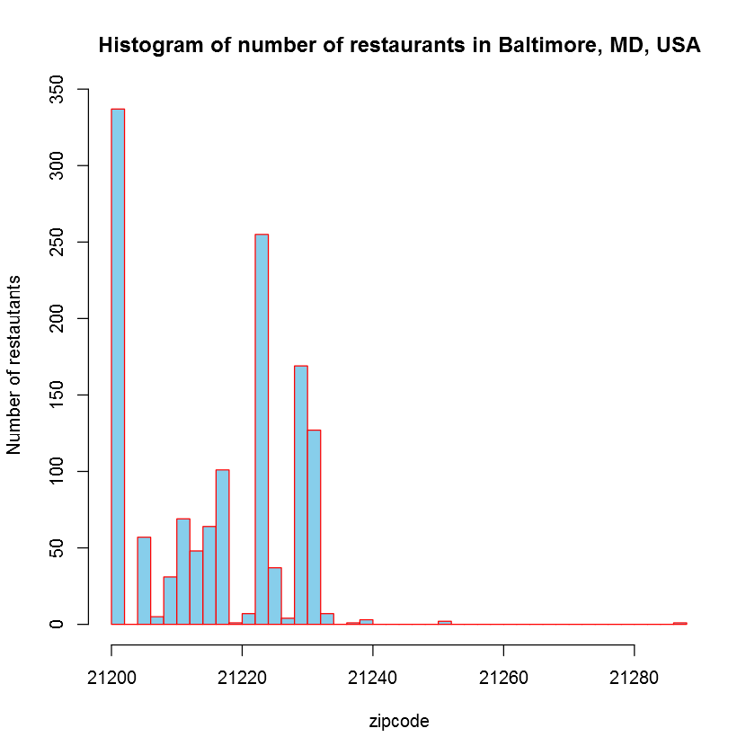

```r
hist(as.numeric(zipcode),breaks=32,xlab='zipcode',
     ylab='Number of restautants',
     main='Histogram of number of restaurants in Baltimore, MD, USA',
     col='skyblue',border='red')
```

### Example 3

##### Reading rows and columns of our choice.

Let's download xlsx binary data by setting the download mode to binary.

The Excel spreadsheet for this example is from Natural Gas Aquisition Program which can be downloaded from https://d396qusza40orc.cloudfront.net/getdata%2Fdata%2FDATA.gov_NGAP.xlsx

Check if the data is already downloaded, else download it.

```r
if(!file.exists('q3.xlsx')){
    url<-"https://d396qusza40orc.cloudfront.net/getdata%2Fdata%2FDATA.gov_NGAP.xlsx "

    download.file(url,destfile = "q3.xlsx", mode='wb')
}
```

Check if the package xlsx is installed, else install it. Then, load xlsx package.

```r
if(!require(xlsx)){
    install.packages('xlsx')
}

library(xlsx)
```

We can read column and row numbers of our interest and do any calculations as shown below.

```r
rowIndex<-18:23
colIndex<- 7:15

dat<-read.xlsx('q3.xlsx',sheetIndex=1,rowIndex = rowIndex,colIndex = colIndex)

sum(dat$Zip*dat$Ext,na.rm=T)
```

36534720

[comments powered by Disqus](http://disqus.com)